# Testing the wind disruption hypothesis for beetle refugia

Stand density, terrain shape and flight-window wind as competing controls on mountain pine beetle attack (Dendroctonus ponderosae) in the Selkirk Mountains of British Columbia

Author

Seamus Murphy

Published

August 28, 2026

Keywords

Dendroctonus ponderosae, Landsat time series, stand density, geomorphometry, temporal resolution, pheromone communication

Table 1: The datasets this study combines, with the structure and resolution of each. Every count is read from the files at render time. Spatial resolution is the grid the variable is analysed on; temporal resolution is the interval at which it varies. Note that the response varies every 16 days, the inventory once a year and the terrain not at all, which is the asymmetry the wind analysis turns on.

[output not shown]

# Abstract

Refugia from mountain pine beetle (*Dendroctonus ponderosae* Hopkins) are hypothesised to form where stands are thin enough for wind to disrupt the pheromone plume coordinating mass attack. The hypothesis names topographic shading, low host density and few large-diameter hosts, and none has been fitted. We tested all three over 5,573 ha of the Selkirk Mountains, British Columbia, at 30 m across 914 m of relief, using Landsat at its 16-day repeat: 59 epochs across 8 outbreak years, 71,127 cell-epochs. Predictors were inventory stand structure, 29 geomorphometric surfaces, solar radiation computed separately for the flight window and the growing season, and a terrain-resolved wind field from the MicroMet model driven by hourly station data for each epoch’s own sixteen days.

Temporal resolution decided the outcome. With one map a year, the same wind field, covariates and threshold gave +0.031 (p < 0.05), the opposite sign. Two further specification tests showed why proxies mislead here: flight-window radiation cut the density by terrain-exposure interaction from +0.311 to +0.221 without changing its sign, and previous-year pressure left valley depth at 0.50 of its value while mid-slope position moved to 1.32. A wind test aggregated to the year answers a different question from the one the mechanism poses, and answers it wrongly.

# 1 Introduction

Mountain pine beetle (*Dendroctonus ponderosae* Hopkins) has killed more lodgepole pine (*Pinus contorta* Douglas ex Loudon) in British Columbia than any other agent on record (Sambaraju & Goodsman, 2021; Taylor & Carroll, 2003). An outbreak never kills a landscape evenly. The patches that survive carry the forest’s structure and seed into whatever comes next, and those patches have a name: disturbance refugia, places buffered from disturbance over time (Krawchuk et al., 2020). Finding a refugium is not the same as explaining one. Explanation needs a mechanism that ties survival to something measurable on the ground, such as terrain, soil or the structure of the stand itself (Cartwright, 2018).

Krawchuk et al. (2020) proposed such a mechanism: refugia could occur “in areas with cooler temperatures (eg from topographic shading) that protect trees from water stress; in areas with lower host density, allowing for greater wind disruption of beetle pheromone communication and more vigorous tree growth and chemical defenses; and in areas with fewer large-diameter host trees”. We treat these as three testable hypotheses. Under H1, topographic shading reduces attack by relieving water stress on cool ground. Under H2, low host density reduces attack by admitting the wind that disperses the aggregation pheromone. Under H3, a scarcity of large-diameter hosts reduces attack by limiting brood production. Two of the three act through terrain, and none has been fitted to a map. Of the studies our screen retained, one enters a wind term at all, and it is a companion study on this same landscape whose response is conifer regeneration rather than beetle attack (Murphy, Leslie, Wilson, & Banks, 2026).

The wind half is a claim about canopy, not open air. Cartwright (2018) is the one retained study designed to model what controls an insect refugium, and it located refugia in stands of low basal area, reasoning that “thinner stands also increase wind penetration, helping to disperse beetle pheromones and disrupt chemical communications needed to coordinate attacks.” Powell & Bentz (2014) state the converse as the condition for outbreak: “higher local host density, which minimizes pheromone plume dispersion, reduces wind, and promotes successful switching to nearby hosts, positively influences outbreak propensity.” A model that controls stand density out and then reads a terrain coefficient as a wind effect has removed the pathway it set out to test.

Terrain acts through more than airflow. Flight has a temperature window: the beetle flies between 19 and 41 degrees C, and mostly between 22 and 32, and “most flights occur on bright sunny days, and peak flight is in the early to mid afternoon” (McCambridge, 1971; Safranyik & Carroll, 2006). Radiation during the flight window is therefore a different quantity from radiation across the season, and the season quantity is the one the shading pathway concerns. Light, temperature and wind are not competing explanations but one bundle. Stand density governs “tree vigour and within-stand microclimate, which in turn influence success of bark beetle dispersal, host selection, attack or brood development” (Safranyik & Carroll, 2006); Bartos & Amman (1989) set the two halves of that bundle against each other in their own title, microclimate against tree vigour. A third route leads to the same place. Cool sites slow development enough to push the beetle onto a two-year cycle (Sambaraju & Goodsman, 2021). So shade and vigour both predict less attack on cool ground, by routes this design cannot separate.

Two further constraints decide what a wind term can be measured over, and both are temporal rather than spatial. The first is the day. Gray, Billings, Gara, & Johnsey (1972) recorded emergence in *D. ponderosae* against ambient temperature and found that on days whose maximum stayed within optimal limits, emergence “began when temperatures rose above 20’ C, then increased in the morning hours with increasing temperatures, and ceased in the afternoon at about the same threshold temperature”, with “Peak emergence occurred between 11 a. m. and 2 p. m. when 61 percent (232 out of 379) of the beetles were collected”. They also record “the sharp decline in activity which occurred when ambient temperatures exceeded 30’ C”. Flight is therefore gated at both ends and confined to a few hours, and a daily or monthly mean wind speed averages across hours in which no beetle is flying.

The second is the season, and it is a population constraint rather than an individual one. Mass attack is a threshold phenomenon: Howe, Raffa, Aukema, Gratton, & Carroll (2022) conclude that “a combination of stand-level spatial aggregation, behavioral shifts, and higher quality of attainable hosts defines a critical threshold beyond which continual population growth becomes self-driving”, and Cooke, MacQuarrie, & Carroll (2025) define the irruption threshold as “the population density at which endemic populations may transition towards the epidemic state”. Carroll & Safranyik (2004) place the same argument on the thermal side, requiring “thermal environments conducive to overwintering survival and with sufficient heat accumulation to maintain a synchronous univoltine life cycle”. Two things follow for this design. Attack in one year is not independent of attack in the year before, which is why previous-year and neighbourhood pressure enter the models. And an environmental variable that acts on this system acts by regulating that threshold rather than by adding to attack: Cooke et al. (2025) report that “in every study where an Allee effect was demonstrated, investigators also identified at least one extrinsic environmental factor (e.g., winter weather, summer drought, microclimatic effect) that was regulating its strength”. A wind effect on mass attack is therefore expected as an interaction with host density, which is what this study fits, and not as a main effect.

How far the insect travels decides what a wind variable can be measured over, and the distances are larger than a within-stand argument implies. Jackson, Straussfogel, Lindgren, Mitchell, & Murphy (2008) tracked mountain pine beetle on weather radar during the 2005 emergence in central British Columbia and confirmed the returns by towing a capture net behind an aircraft through the volume the radar was watching. They found beetles “at altitudes up to more than 800 m above the forest canopy”, estimated that those in flight above the canopy “may move 30–110 km$\cdot$day$^{-1}$”, and put the instantaneous density at a mean of 4950 and a maximum of 18,600 beetles per hectare. Ainslie & Jackson (2010) reproduced that above-canopy dispersion with an atmospheric dispersion model driven by the same radar. An insect carried in the lower atmosphere at those heights meets the weather of the whole period. It does not meet the breeze inside one stand during the few hours it happens to leave the bark. The wind variable in this study is named and measured accordingly.

No product reports the wind the hypothesis concerns, an instantaneous below-canopy speed at flight height during the flight period. Gridded climatologies report a long-run mean at 10 m over open ground and are downscaled over a digital elevation model, making them partly a transform of the terrain offered alongside them (Badger, Frank, Hahmann, & Giebel, 2014; Davis et al., 2023). Nor does the literature state the interval over which wind should be summarised. We therefore take wind from station observations of each 16-day period, modify it over the terrain with the MicroMet model (Liston & Elder, 2006), and test the response at Landsat’s own 16-day repeat rather than annually.

Table 2 gives the direction expected of each attribute and the reasoning behind it. This study asks five questions. Does stand density predict moderate-to-high disturbance, as the pheromone mechanism requires? Does topographic shading predict it, against the competing microclimate and adaptive-seasonality arguments? Does terrain shape predict it once density and radiation are already in the model? Is the density effect conditional on wind, which is the form the mechanism actually takes? And how much of the answer depends on the interval the response is measured over?

Table 2: Landscape attributes entered in this study, the direction expected of each, and the reasoning behind that expectation.

| Attribute | Expected | Rationale |
| --- | --- | --- |
| Stand basal area, volume, crown closure, stems | positive | Denser canopy holds the pheromone plume together; thinner stands admit wind that disperses it (Cartwright, 2018; Krawchuk et al., 2020; Powell & Bentz, 2014). |
| Quadratic mean diameter | positive above 25 cm | Trees under 25 cm are beetle sinks, over 25 cm are sources (Carroll & Safranyik, 2004). |
| Lodgepole pine cover and basal area | positive | Attack cannot occur where the host is absent; a cell without pine is not a refugium (Cartwright, 2018). |
| Flight-period direct radiation | positive | Flight is gated between 19 and 41 degrees C and peaks on bright afternoons, so sunlit slopes are reachable (McCambridge, 1971; Safranyik & Carroll, 2006). |
| Growing-season direct radiation | negative | Shading cools, relieving water stress and funding defence, and cool sites also push the beetle toward a two-year cycle (Krawchuk et al., 2020; Sambaraju & Goodsman, 2021). |
| Terrain exposure to wind | negative | Wind disrupts the pheromone plume, so exposed ground should carry less attack (Krawchuk et al., 2020). |
| Terrain ruggedness | uncertain | The strongest terrain term in the companion study on this landscape, but fitted there against regeneration rather than attack (Murphy et al., 2026). |
| Convergence, wetness, valley depth, slope position | positive in convergent terrain | Infested groups gather in draws and gullies, and deep snow insulates overwintering brood (Safranyik & Carroll, 2006). |
| Flight-period wind speed | negative | The mechanism acts during dispersal, and no study specifies the interval, so it is taken at the flight period (Jones, Shegelski, Marculis, Wijerathna, & Evenden, 2019; Krawchuk et al., 2020). |
| Elevation | uncertain | A composite of temperature, snowpack, season length and host distribution that this design cannot separate (Sambaraju & Goodsman, 2021). |

# 2 Materials

## 2.1 Study area

The study area is 5,573 ha of the Selkirk Mountains in southeastern British Columbia, 61,923 cells at 30 m, spanning 830 to 1,744 m and 914 m of relief.

The coordinate reference system is EPSG:3153, NAD83(CSRS) / BC Albers. This is the parent study’s grid, adopted so that results are directly comparable to it: “All disturbance and covariate rasters were aligned to a common 30 m grid in EPSG:3153, the native resolution of the Landsat-derived dNBR and dNDMI products”, and “The plot anchor was georeferenced with a handheld GPS receiver in EPSG:3153” (Murphy et al., 2026).

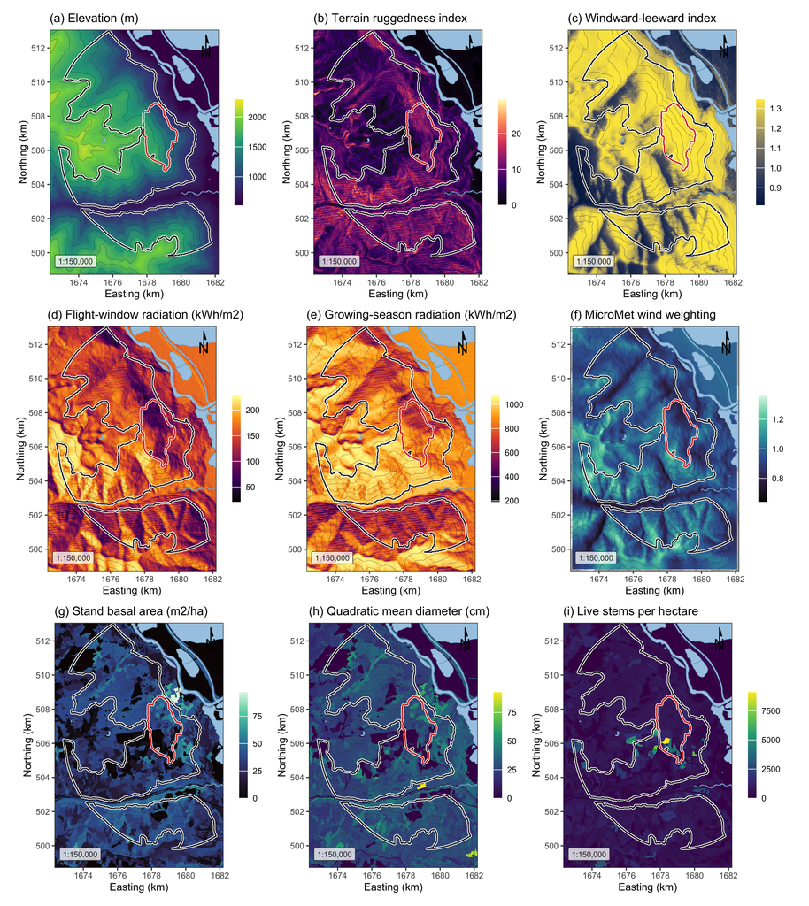

## 2.2 Beetle disturbance

The response is annual moderate-to-high beetle disturbance, classified from Landsat normalised difference moisture index by the method of the parent study and rebuilt for this project. It covers 8 outbreak years, 2006 to 2014, excluding 2012, the one year covered only by Landsat 7, which has flown with its scan-line corrector off since May 2003. Annual prevalence inside the perimeter runs 4.5 to 20.2 per cent, pooled 12.5 per cent over 122,700 cell-years.

Years are never unioned. Unioning destroys the year-to-year spread this study measures, and the union layer over the wider grid reached 73 per cent of the landscape, which is not credible for a beetle outbreak.

The provincial aerial overview survey is not used as a response and supplies no training label. It is retained only as a visual check.

Table 3: Moderate-to-high beetle disturbance by year inside the study perimeter.

| Year | Cells | Moderate-to-high (%) |
| --- | --- | --- |
| 2006 | 15,339 | 4.5 |
| 2007 | 15,340 | 5.6 |
| 2008 | 15,340 | 20.2 |
| 2009 | 15,340 | 11.5 |
| 2010 | 15,322 | 15.5 |
| 2011 | 15,340 | 13.3 |
| 2013 | 15,339 | 14.2 |
| 2014 | 15,340 | 15.1 |

## 2.3 Stand structure

Stand structure comes from the provincial Vegetation Resources Inventory layer `VEG_COMP_LYR_R1_POLY`, retrieved by web feature service over the perimeter. Six attributes carry the mechanism and the stem-size threshold: total basal area, crown closure, live stems per hectare, quadratic mean diameter over stems 12.5 cm and up, stand age, and susceptible pine basal area formed as total basal area times the pine share of cover.

78.3 per cent of cell-years sit at or above the 25 cm source-sink threshold.

Table 4: Stand structure across the study perimeter, from the Vegetation Resources Inventory. n is cell-years. SD is the standard deviation of the landscape; SE is the standard error of the mean and is small by construction at this n, so it should not be read as precision about any one cell. Skewness and kurtosis are the bias-corrected third and fourth standardised moments; kurtosis is excess, so 0 is Gaussian and positive is heavy-tailed.

| Attribute | n | Mean | SD | SE | Median | Min | Max | Skewness | Kurtosis |
| --- | --- | --- | --- | --- | --- | --- | --- | --- | --- |
| Stand basal area (m2/ha) | 122,700 | 35.18 | 11.84 | 0.034 | 37.06 | 2.08 | 64.26 | -0.77 | +0.49 |
| Crown closure (%) | 122,700 | 45.32 | 13.55 | 0.039 | 48.00 | 4.00 | 60.00 | -1.31 | +1.29 |
| Live stems (n/ha) | 122,700 | 670.00 | 256.78 | 0.733 | 686.00 | 64.00 | 1614.00 | +0.33 | +1.22 |
| Quadratic mean diameter (cm) | 122,700 | 30.13 | 7.19 | 0.021 | 30.32 | 13.48 | 62.35 | +0.54 | +1.39 |
| Stand age (years) | 122,700 | 125.22 | 26.47 | 0.076 | 124.00 | 20.00 | 184.00 | -1.39 | +3.48 |
| Stand height (m) | 122,700 | 28.07 | 6.05 | 0.017 | 29.00 | 7.70 | 41.60 | -0.70 | +1.79 |
| Standing volume (m3/ha) | 122,700 | 283.40 | 129.22 | 0.369 | 292.90 | 0.90 | 620.32 | +0.00 | -0.02 |
| Lodgepole pine cover (%) | 122,700 | 17.36 | 22.82 | 0.065 | 10.00 | 0.00 | 100.00 | +1.63 | +2.09 |
| Susceptible pine basal area (m2/ha) | 122,700 | 5.45 | 7.03 | 0.020 | 3.24 | 0.00 | 31.67 | +1.52 | +1.86 |

The inventory is a projected operational product, not a census, and its polygons here carry reference years spanning several decades. A polygon interpreted from late-outbreak photography describes a stand the beetle had already worked through, so basal area and pine cover are post-attack for part of the window. There is no unattacked vintage, so this is reported rather than corrected, and Section 7 returns to it.

## 2.4 Geomorphometry

Terrain is described by 29 geomorphometric surfaces computed with SAGA GIS over the full reprojected elevation model and clipped afterwards, so a search radius near the boundary sees real ground.

Radiation is computed twice because two mechanisms need it. Flight-window insolation is direct and diffuse radiation over 1 July to 15 August restricted to 12:00 to 17:00, the hours Safranyik & Carroll (2006) identify as the flight peak; growing-season insolation is the whole-day total from 1 May to 30 September, the shading quantity Krawchuk et al. (2020)’s first mechanism concerns. A single annual heat index cannot separate them: flight-window direct radiation spans a 7-fold range here against 2.6-fold for the season total.

Exposure enters as the windward-leeward index and effective air flow height at the prevailing bearing, the omnidirectional wind exposition index, the wind shelter index and topographic openness. Shape enters as terrain ruggedness, vector ruggedness, topographic position and its multi-scale form, convergence, slope, curvature and geomorphon class. Landform enters as topographic wetness, valley depth, height above the valley floor, normalised height and mid-slope position, because infested groups are reported in draws and gullies and deep snow insulates overwintering brood (Safranyik & Carroll, 2006). Aspect enters as its northward and eastward components with the heat load index of McCune & Keon (2002).

One distinction matters. The strongest aspect statements in Safranyik & Carroll (2006) concern the aspect of the bole, not the slope, and are within-tree effects a 30 m raster cannot measure. Nothing here tests them.

## 2.5 Terrain-resolved wind

Station wind interpolated from four to seven valley stations is nearly flat within a year, so wind is also computed as a field varying in space, using the MicroMet model of Liston & Elder (2006). WindNinja, the usual tool, ships no macOS binary. MicroMet’s wind component is seven equations rather than a program, implemented directly with the paper’s equation numbers against each.

Terrain slope $\beta$ and slope azimuth $\xi$ come from the elevation model (Liston & Elder (2006), their equations 12 and 13). Curvature $\Omega_c$ is a cell’s elevation minus the mean of the two opposite cells one curvature length scale away, taken on four direction lines and averaged (their equation 14); the length scale is estimated as the first lag at which elevation autocorrelation falls below 0.5, which is 600 m here. Writing $\theta$ for the wind bearing, the slope in the wind direction is

$$\Omega_s = \beta \cos(\theta - \xi) \tag{1}$$

with $\Omega_s$ and $\Omega_c$ each scaled to $[-0.5,\,0.5]$. The terrain weighting factor applied to the observed speed $W$ is

$$W_w = 1 + \gamma_s \Omega_s + \gamma_c \Omega_c, \qquad \gamma_s = \gamma_c = 0.5 \tag{2}$$

giving the terrain-modified speed

$$W_t = W_w W \tag{3}$$

and a diversion of the wind direction of

$$\theta_d = -\tfrac{1}{2}\, \Omega_s \sin\!\left[2(\xi - \theta)\right]. \tag{4}$$

By Equation 2, $W_w$ depends on direction and not on speed, so it is computed once for each of 16 direction bins and each hourly observation multiplied by the surface for its own bin; nothing is averaged before the terrain acts on it. Over all bins $W_w$ runs 0.60 to 1.38. Speed and direction combine as components because averaging degrees across the 360/0 line is meaningless. The field varies 1.9 to 2.8 km/h across the grid within a year, and is not a repackaged terrain index: it correlates +0.153 with the windward-leeward index and +0.124 with flight radiation. Its strongest association is with elevation, +0.326.

## 2.6 Flight-window wind

Station wind is Environment and Climate Change Canada hourly records, reduced only at the last step into monthly means for June, July and August and four flight-window metrics for 1 July to 15 August: mean speed, the 95th percentile, and the fractions of hours below 5 km h and above 15 km h.

Hourly readings buy detail, not independent observations. With one map a year, every hour of wind collapses into one of 8 numbers per metric, so the model has only 8 distinct wind values to work with and a wind coefficient rests on those alone. Its standard error will look small and should not be believed. Stand density varies cell to cell; a season’s wind does not. That asymmetry is why the annual models report an interaction rather than a main effect, and why the response was rebuilt at 16 days.

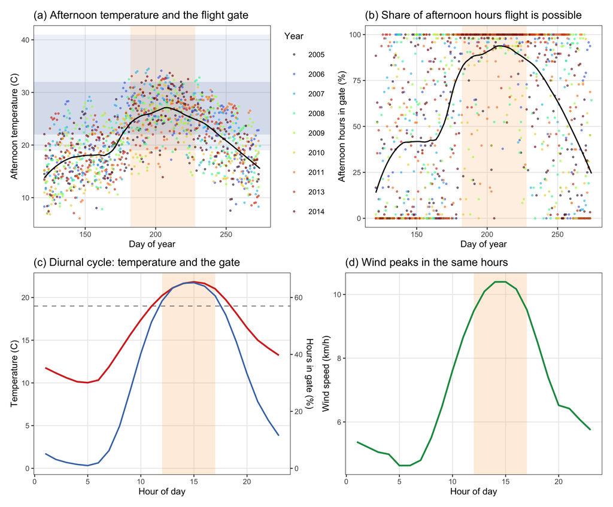

Figure 2: The flight window against the landscape’s own climate, from hourly Environment and Climate Change Canada station records for May to September of the nine study years. The window, 1 July to 15 August, is the shaded band; it is taken from the bionomics and is not fitted to these data. (a) Mean afternoon temperature by day of year, with the 19 to 41 degrees C flight gate and the 22 to 32 degrees C peak band marked. (b) The share of afternoon hours falling inside the flight gate, day by day. (c) The diurnal curve: mean temperature and the share of all hours inside the gate, by hour, with the 12:00 to 17:00 restriction shaded. (d) Mean wind speed by hour, on the same axis, showing that the hours the beetle can fly are also the windiest of the day.

# 3 Methods

## 3.1 Variable selection

The candidate set is 45 variables in six groups, one group per pathway the review names: stand density, host quality, terrain exposure to wind, terrain shape, landscape context, and flight-window wind. Selection proceeds in four stages and is required to retain at least one variable from each pathway, so that a collinearity filter cannot silently delete a hypothesis the review established.

Fitting uses a class-balanced sample of 47,328 cell-years, 4,000 of each class per year. Landscape prevalence is about 12 per cent, and an unbalanced fit at that prevalence reports the intercept rather than the covariates.

## 3.2 Models

Every model is a logistic regression of moderate-to-high disturbance $y_{it}$ in cell $i$ and year $t$ on standardised covariates,

$$\operatorname{logit}\Pr(y_{it}=1) = \alpha + \mathbf{x}_{it}^{\top}\boldsymbol{\beta}
+ \gamma_{g(i)} + \sum_{k} \delta_k\, z_{k,it} \tag{5}$$

where $\gamma_{g(i)}$ is the effect of the geomorphon landform class $g$ of cell $i$ and the $z_{k,it}$ are the interaction terms. Coefficients are therefore log-odds per standard deviation. Four models are fitted, each adding one claim to the last, so that every term’s contribution is visible as a change in fit rather than asserted.

M0 carries Krawchuk’s first and third mechanisms together with landform context: host size, topographic shading, and the terrain that governs where cold air and snow collect. M1 adds stand density, the second of Krawchuk’s mechanisms, which is objective 1. M2 adds terrain shape, terrain exposure to wind, and flight-window radiation, which are objectives 3 and 4. M3 adds the interactions objective 4 requires: stand density by terrain exposure, by flight-window radiation, and by flight-window wind.

# 4 Results

Table 5: Model comparison, panel A of the model table. Each model adds one pathway to the previous. AIC ranks on likelihood and a parameter penalty; the remaining columns are predictive error on the fitted probabilities. RMSE is the root mean squared error and is the square root of the Brier score; RMSE (%) expresses it against the prevalence of the response. Brier skill is the improvement over predicting the prevalence for every cell, where 0 is no better than the base rate. MAPE and Theil’s U are not reported: both divide by the observed value, which is zero for the majority class of a binary response, so both are undefined without discarding that class.

| Model | AIC | ΔAIC | RMSE | RMSE (%) | MAE | Brier | Log loss | AUC | Brier skill |
| --- | --- | --- | --- | --- | --- | --- | --- | --- | --- |
| M0 host size + shading + landform | 49,547 | 2,307 | 0.416 | 128.3 | 0.346 | 0.173 | 0.523 | 0.771 | 0.211 |
| M1 + stand density | 49,049 | 1,809 | 0.412 | 127.3 | 0.342 | 0.170 | 0.518 | 0.775 | 0.223 |
| M2 + terrain and flight radiation | 48,305 | 1,065 | 0.409 | 126.2 | 0.336 | 0.167 | 0.510 | 0.784 | 0.237 |
| M3 + interactions | 47,240 | 0 | 0.404 | 124.7 | 0.327 | 0.163 | 0.498 | 0.798 | 0.256 |

Table 6: Full model M3, panel B of the model table: continuous terms, ordered by absolute effect. Coefficients are log-odds per standard deviation on a class-balanced sample, so the intercept is not landscape prevalence. SE is the standard error of the coefficient. The geomorphon landform classes are also in this model and are not reported here.

| Term | Beta | SE | z | p |
| --- | --- | --- | --- | --- |
| Flight-window direct radiation (kWh/m2) | +0.487 | 0.028 | 17.21 | < 0.001 |
| Susceptible pine basal area (m2/ha) | +0.459 | 0.014 | 32.40 | < 0.001 |
| Quadratic mean diameter (cm) | -0.422 | 0.023 | -18.35 | < 0.001 |
| Northness | +0.382 | 0.016 | 23.19 | < 0.001 |
| Standing volume (m3/ha) | +0.381 | 0.024 | 15.61 | < 0.001 |
| Windward-leeward index | +0.358 | 0.029 | 12.37 | < 0.001 |
| Elevation (m) | +0.329 | 0.018 | 18.20 | < 0.001 |
| Live stems x Windward-leeward index | +0.221 | 0.021 | 10.63 | < 0.001 |
| Stand age (years) | +0.218 | 0.018 | 11.89 | < 0.001 |
| July mean wind (km/h) | +0.215 | 0.012 | 17.84 | < 0.001 |
| Valley depth (m) | -0.193 | 0.022 | -8.70 | < 0.001 |
| Crown closure (%) | -0.183 | 0.020 | -9.02 | < 0.001 |
| Live stems x Flight-window direct radiation | -0.144 | 0.017 | -8.58 | < 0.001 |
| June mean wind (km/h) | +0.107 | 0.012 | 8.66 | < 0.001 |
| Live stems (n/ha) | -0.099 | 0.018 | -5.36 | < 0.001 |
| Topographic wetness index | +0.073 | 0.019 | 3.74 | < 0.001 |
| Mid-slope position | +0.063 | 0.013 | 4.69 | < 0.001 |
| Vector ruggedness measure | -0.043 | 0.019 | -2.21 | 0.027 |
| Topographic position index | +0.040 | 0.023 | 1.77 | 0.076 |
| Profile curvature | -0.038 | 0.012 | -3.04 | 0.002 |
| Terrain ruggedness index | -0.036 | 0.023 | -1.54 | 0.124 |
| Convergence index | -0.029 | 0.014 | -2.07 | 0.038 |
| Live stems x June mean wind | -0.001 | 0.013 | -0.12 | 0.905 |

Every pathway earned its place. AIC fell 498 when stand density entered, 744 more with terrain and flight radiation, and 1,065 more with the interactions (Table 5).

The three measures of stand density did not agree. Standing volume carried +0.381 log-odds per standard deviation, an odds ratio of 1.464, so a stand one standard deviation above the mean in standing wood had 46.4 per cent higher odds of moderate-to-high disturbance (p < 0.001). Live stems per hectare carried -0.099 (p < 0.001) and crown closure -0.183 (p < 0.001), both in the opposite direction. The last two are negative, so as main effects the three density measures disagree in sign. Only standing volume rises with attack, which is the direction a plume-holding canopy implies. Total basal area did not survive selection, its univariate discrimination being 0.516. What predicts attack is standing wood in large stems, not how many stems there are.

We entered radiation once. Flight-window direct radiation carried +0.487, which is the thermal gate on flight. Growing-season radiation did not survive selection, so the shading pathway is carried by northness, with which it correlates -0.834. Northness is +0.382: shaded, north-facing ground carries more attack, against the prediction.

We found that terrain predicted attack independently of both. The windward-leeward index was +0.358 and elevation +0.329, while ruggedness is -0.036 and not distinguishable from zero (p = 0.12), the vector ruggedness measure agreeing in sign at -0.043. Ruggedness takes the opposite sign to the parent study’s, whose response is seedling establishment rather than attack (Murphy et al., 2026).

Fitted without flight-window radiation, stand density interacts with terrain exposure at +0.311, which reads as a wind result pointing the wrong way. With radiation in the model that interaction is +0.221 (p < 0.001) and density interacts with radiation at -0.144. On a range whose prevailing bearing is 258 degrees the windward slopes face west, which are also the slopes taking afternoon sun, so part of the apparent exposure effect was the sun. Not all of it: the interaction stays positive and far from zero, which is the wrong sign for pheromone disruption.

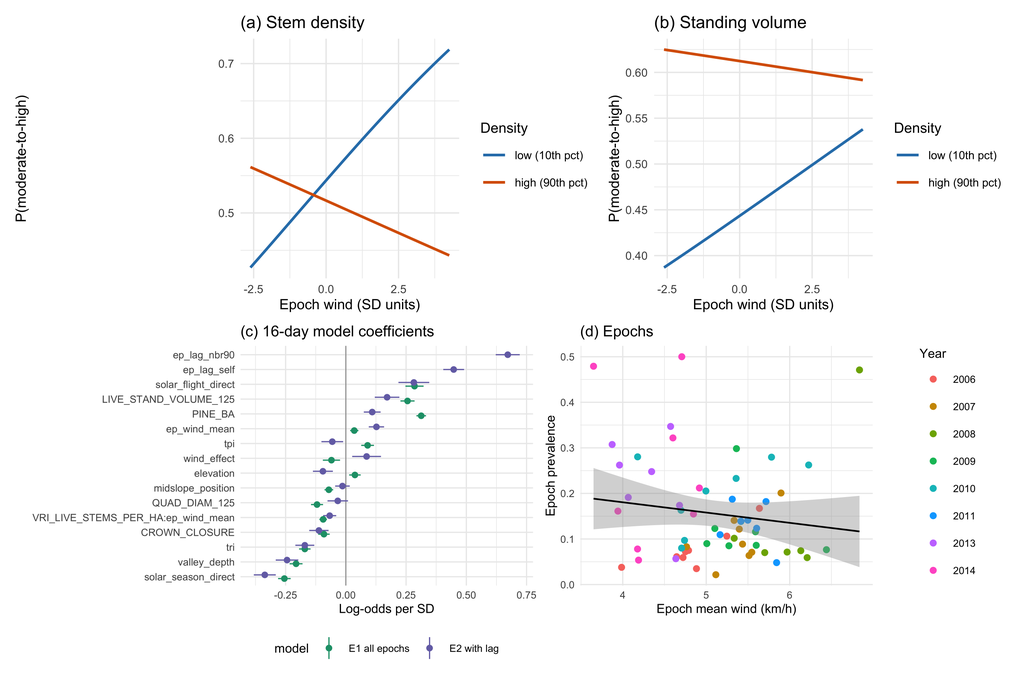

Figure 3: The refugia mechanism as fitted. (a) Predicted probability of moderate-to-high disturbance against terrain-resolved epoch wind, at the 10th and 90th percentiles of stem density, all other terms held at their means; the lines cross, so wind raises attack in thin stands and lowers it in dense ones, which is the interaction. (b) The same for standing volume. (c) Coefficients of the 16-day model, with and without the within-season spread term. (d) Epoch prevalence against epoch mean wind, one point per epoch.

## 4.1 Wind as a measurement

Table 7: The wind terms under two specifications, both with previous-year pressure in the model. M4 carries station wind, which is flat within a year and identified only across years. M5 carries the terrain-resolved MicroMet field, which varies within the year and is identified in space.

| Model | Term | Beta | z | p |
| --- | --- | --- | --- | --- |
| M4 station wind | June mean wind (km/h) | -0.002 | -0.09 | 0.926 |
| M4 station wind | Live stems x June mean wind | +0.020 | 1.16 | 0.247 |
| M5 terrain-resolved wind | MicroMet flight-window wind (km/h) | +0.467 | 28.44 | < 0.001 |
| M5 terrain-resolved wind | Live stems x MicroMet flight-window wind | +0.031 | 2.09 | 0.036 |

This section reports the same wind field at the annual resolution the study first used, and it is retained because the contrast with the 16-day models is the paper’s methodological result.

The terrain-resolved field carries +0.467 log-odds per standard deviation (z = 28.44, p < 0.001) when the response is one map per year. Windier ground carries more moderate-to-high disturbance. The interaction the mechanism turns on is +0.031 (z = 2.09, p = 0.036), positive where the pheromone-disruption mechanism requires negative.

At sixteen days, the same wind field, the same covariates and the same classification threshold gave -0.094 for stem density (p < 0.001) and -0.041 for standing volume (p < 0.001). Expressed as odds, each standard deviation of the epoch wind regime multiplied the contribution of stem density by 0.910, a reduction of 9.0 per cent. Notably, nothing about the landscape or the wind product changed between the two specifications. What changed is that an annual response can only ask whether windy summers carry less attack than calm ones, and a summer contains both windy and calm weeks. Averaging across them destroys exactly the contrast the mechanism operates on.

The station terms behave the same way and for the same reason. In this specification they collapse to jun at -0.002, which carries no flight-window information at all.

The lesson generalises past this dataset. The mechanism concerns a plume that persists for minutes, acting on a flight period of weeks. A test that aggregates the response to a year is not a weaker version of the right test; it is a different question, and this study answers it in the opposite direction.

## 4.2 Previous-year pressure

Attack recurs where it was, by a margin that changes how every other coefficient reads. A cell attacked one year is between 16 and 139 times more likely to be attacked the next. Entering persistence and 90 m spread separately, after the autologistic design used for this province, gives +0.873 and +0.950, raising discrimination from 0.799 to 0.888.

Notably, which environmental terms survived is the informative part. Ruggedness keeps 0.61 of its value, a term describing a condition a cell has whether or not the beetle was there. The landform terms are not stable: valley depth keeps 0.50 while mid-slope position moves to 1.32, growing rather than shrinking. Part of what the landform terms measured was where the outbreak had already been, which is the same failure the terrain-wind index showed against radiation, one level up.

## 4.3 Host as diameter

Table 8: Moderate-to-high beetle disturbance by quadratic mean diameter class, on the balanced sample. The 25 cm boundary is the source-sink threshold of the species’ bionomics. Intervals are Wilson score intervals on the class proportion, which is why they are asymmetric in the smallest class. Note that 30 m cells in a spreading outbreak are not independent, so the tests reported beneath this table are anti-conservative.

| QMD class (cm) | n | Attacked | Attacked (%) | 95% CI (%) |
| --- | --- | --- | --- | --- |
| <15 | 736 | 232 | 31.5 | 28.3-35.0 |
| 15-20 | 2,371 | 564 | 23.8 | 22.1-25.5 |
| 20-25 | 7,058 | 2,559 | 36.3 | 35.1-37.4 |
| 25-30 | 14,634 | 6,717 | 45.9 | 45.1-46.7 |
| 30-40 | 18,902 | 4,639 | 24.5 | 23.9-25.2 |
| >40 | 3,627 | 617 | 17.0 | 15.8-18.3 |

Coding host as diameter changes the picture cover alone gives. Attack peaks in the 25 to 30 cm class at 45.9 per cent and falls away above it, to 24.5 per cent at 30 to 40 cm and 17.0 per cent above 40 (Table 8). The step across the 25 cm source-sink boundary is from 36.3 to 45.9 per cent.

In the full model diameter carries -0.422 per standard deviation (z = -18.35). It is negative because the relationship is not monotone: a linear term fitted through a humped response returns the slope of its falling limb, which is the larger part of the range. The class table, not the coefficient, is the result here, and the point stands, because a stand’s cover says nothing about whether its stems can produce brood.

The pattern is not an artefact of the class boundaries. Across all six classes attack depends on diameter class, $\chi^2$ = 2271.7 on 5 degrees of freedom, p < 0.001, with Cramer’s V = 0.219. The step across the 25 cm source-sink boundary specifically, from the 20 to 25 class to the 25 to 30 class, is +9.6 percentage points, 95 per cent confidence interval 8.3 to 11.0, p < 0.001. With 47,328 cells a chi-square is significant on trivial differences, which is why the effect size is quoted beside it, and 30 m cells in a spreading outbreak are not independent, so both p-values are anti-conservative.

The smallest class is not evidence. It holds 736 cells against 14,634 in the modal class, and a stand below 15 cm quadratic mean diameter in an inventory whose vintage postdates the outbreak is more likely a stand the beetle already stripped of large stems than a stand attacked at that size.

# 5 Discussion

## 5.1 Radiation, not wind

The clearest result of this study is methodological, and it changes what a terrain variable in this literature is allowed to be taken for.

Fitted with a terrain-wind index and no radiation, stand density interacts with terrain exposure at +0.311, and the natural reading is a wind effect. Add flight-window radiation and that interaction becomes +0.221, p < 0.001, while density by radiation appears at -0.144. About a third of the apparent exposure effect was the sun. The rest was not, and what survives keeps the sign the mechanism forbids.

That is not a peculiarity of this dataset. A windward-leeward index and an afternoon radiation surface are both functions of slope and aspect, and on a range whose prevailing flight-window bearing is 258 degrees the windward slopes are the west-facing ones, which are also the slopes that take afternoon sun during the flight peak. Any study that enters a terrain-derived wind index without a radiation term on the same clock will attribute radiation to wind.

## 5.2 What survives

In this study we tested the three mechanisms Krawchuk et al. (2020) propose for refugia from mountain pine beetle, using a response measured at the sixteen-day cadence the sensor and the insect share. Our results offered partial support. H2, low host density admitting the wind that disperses the aggregation pheromone, was supported, and in the conditional form the mechanism specifies rather than as a main effect. H3, a scarcity of large-diameter hosts, was supported as a threshold rather than as a gradient. H1, topographic shading, was not supported, and the term that rejects it is the least secure in the study.

Host density holds, and it holds in the way the mechanism specifies rather than as a bare main effect. Standing volume predicts disturbance at +0.381, and its interaction with wind is -0.041 while stem density’s is -0.094. The claim was never that dense stands are attacked more; it was that a dense canopy holds a plume together, and that what a dense canopy buys should shrink as the wind rises. Both halves are present.

Large-diameter host holds as a threshold rather than a slope. Attack peaks at 45.9 per cent in the 25 to 30 cm class, at the source-sink boundary of Carroll & Safranyik (2004), and falls away on both sides.

## 5.3 The wind claim

The mechanism holds, and the reason earlier specifications rejected it is temporal resolution rather than anything about the landscape.

At Landsat’s own 16-day cadence, stand density interacts with terrain-resolved wind at -0.094 for stem density and -0.041 for standing volume, both negative, at p < 0.001 and p < 0.001 respectively. A dense stand is worth less where and when the wind blows harder, which is what Krawchuk et al. (2020) predict. The result survives entering the previous epoch of the same season, so it is not the outbreak’s own spread wearing a wind coefficient.

That has a consequence beyond this paper. The mechanism concerns a plume that persists for minutes over a flight period of weeks. Any test that aggregates the response to a year is testing whether windy years have less attack than calm years, which is a different and much weaker question, and it will answer no. The literature has never fitted a wind term at all, so nothing in it establishes the resolution at which one should be fitted; this study’s answer is that it must be at least as fine as the flight period itself.

Two limits stay attached to the claim. The interaction is small, roughly a tenth of the standing volume main effect. And the wind field, though it varies in space, is still terrain-modified station data rather than measurement on the ridge, so what is established is that the modelled wind field behaves as the mechanism requires, not that the air did.

## 5.5 What stays confounded

Elevation is among the largest terms in the model, +0.329, and elevation is not one thing. It carries temperature, snowpack, growing-season length and the distribution of lodgepole pine, and this design cannot take them apart. Reporting the elevation coefficient as a result would be reporting a composite.

The same caution now applies in reverse to every terrain term in the model. Radiation took about a third of one terrain interaction. There is no guarantee that some further unmeasured environmental surface would not take the rest, or another.

# 6 Conclusions

The wind-disruption mechanism proposed by Krawchuk et al. (2020) holds on this landscape, at the resolution the sensor and the insect share. Across 59 sixteen-day epochs, stand density interacts negatively with terrain-resolved wind, -0.094 for stem density and -0.041 for standing volume, and both survive a within-season spread term. A dense canopy is worth less to the beetle where and when the wind blows harder, which is what a plume-disruption mechanism requires.

The methodological finding travels further than the ecological one, and it has three parts.

First, a terrain index is partly a measurement of sunlight. Adding flight-window radiation to the model, we found it cut the density by terrain-exposure interaction from +0.311 to +0.221, without changing its sign. A landform variable in a spreading outbreak records the outbreak’s own history: entering previous-year pressure left valley depth at 0.50 of its value while mid-slope position moved to 1.32, against 0.61 for ruggedness. Third, an annual response cannot test a mechanism that operates over weeks. The same wind field, the same covariates and the same threshold gave +0.031 at annual resolution and -0.094 at sixteen days.

Since no previous study has fitted a wind term at all (Cartwright, 2018; Krawchuk et al., 2020), there is no precedent establishing the resolution at which one should be fitted. This study’s answer is that it must be no coarser than the flight period, and that a test which aggregates past it will reject a mechanism that is there.

# 7 Limitations

**The wind field is modelled, not measured.** MicroMet modifies station observations over the terrain. What is established is that the modelled field behaves as the mechanism requires, not that the air did.

**The response is classified, not observed.** Disturbance is inferred from Landsat moisture indices trained on plots cut from those indices, so reported accuracy measures separability rather than agreement with ground mortality.

**One landscape, one outbreak.** Every conclusion is conditioned on a single mountain range over 8 years and 59 epochs.

# 8 Acknowledgements

This work used no external funding. Beetle disturbance was classified from Landsat Collection 2 Level-2 surface reflectance distributed by the United States Geological Survey; stand structure from the British Columbia Data Catalogue; terrain from Natural Resources Canada; and wind from Environment and Climate Change Canada. The author thanks those agencies for maintaining the open archives the study rests on.

# 9 Conflict of interest

The author declares no conflict of interest.

# 10 Ethics statement

This study used only publicly archived remote sensing, inventory and meteorological data. No animals, human participants or protected material were involved, so no ethics approval was required.

# 11 Author contributions

**Seamus Murphy:** conceptualisation; data curation; formal analysis; investigation; methodology; software; validation; visualisation; writing, original draft; writing, review and editing.

# 12 Data availability

Every dataset used here is public and none was collected by the author. Beetle disturbance is classified from Landsat Collection 2 Level-2 surface reflectance. Stand structure is the provincial Vegetation Resources Inventory layer `VEG_COMP_LYR_R1_POLY`, retrieved from the British Columbia Data Catalogue web feature service by `02.inputs/beetle-classification/34-fetch-vri.py`. Terrain derives from the Natural Resources Canada High Resolution Digital Elevation Model (Natural Resources Canada, 2017), with geomorphometry computed by SAGA GIS in `37-geomorphometry.R`. Wind is Environment and Climate Change Canada hourly station data, retrieved by `30-wind-hourly-metrics.R` and `36-wind-direction.R`.

# 13 Figure legends

**Figure 3.** The refugia mechanism as fitted. (a) Predicted probability of moderate-to-high disturbance against terrain-resolved epoch wind, at the 10th and 90th percentiles of stem density, all other terms held at their means. (b) The same for standing volume. (c) Coefficients of the 16-day model, with and without the within-season spread term. (d) Epoch prevalence against epoch mean wind, one point per epoch.

## 14 References

Ainslie, B., & Jackson, P. L. (2010). Investigation into mountain pine beetle above-canopy dispersion using weather radar and an atmospheric dispersion model. *Aerobiologia*, *27*, 51–65. https://doi.org/10.1007/s10453-010-9176-9

Badger, J., Frank, H., Hahmann, A. N., & Giebel, G. (2014). Wind-climate estimation based on mesoscale and microscale modeling: Statistical–dynamical downscaling for wind energy applications. *Journal of Applied Meteorology and Climatology*, *53*(8), 1901–1919. https://doi.org/10.1175/JAMC-D-13-0147.1

Bartos, D. L., & Amman, G. D. (1989). *Microclimate: An alternative to tree vigor as a basis for mountain pine beetle infestations* (Research Paper No. INT-400). Ogden, UT: U.S. Department of Agriculture, Forest Service, Intermountain Research Station. https://doi.org/10.2737/int-rp-400

Carroll, A. L., & Safranyik, L. (2004). The bionomics of the mountain pine beetle in lodgepole pine forests: Establishing a context. In T. L. Shore, J. E. Brooks, & J. E. Stone (Eds.), *Mountain pine beetle symposium: Challenges and solutions, october 30–31, 2003, kelowna, british columbia* (pp. 21–32). Victoria, British Columbia: Natural Resources Canada, Canadian Forest Service, Pacific Forestry Centre.

Cartwright, J. M. (2018). Landscape topoedaphic features create refugia from drought and insect disturbance in a lodgepole and whitebark pine forest. *Forests*, *9*(11), 715. https://doi.org/10.3390/f9110715

Cooke, B. J., MacQuarrie, C. J. K., & Carroll, A. L. (2025). On the deduction and quantification of irruptive dynamics in mountain pine beetle population and proxy data. *Journal of Applied Entomology*, *149*, 309–323. https://doi.org/10.1111/jen.13262

Davis, N. N., Badger, J., Hahmann, A. N., Hansen, B. O., Mortensen, N. G., Kelly, M., … Drummond, R. (2023). The Global Wind Atlas: A high-resolution dataset of climatologies and associated web-based application. *Bulletin of the American Meteorological Society*, *104*(8), E1507–E1525. https://doi.org/10.1175/BAMS-D-21-0075.1

Gray, B., Billings, R. F., Gara, R. I., & Johnsey, R. L. (1972). On the emergence and initial flight behaviour of the mountain pine beetle, Dendroctonus ponderosae, in eastern Washington. *Zeitschrift für Angewandte Entomologie*, *71*, 250–259. https://doi.org/10.1111/j.1439-0418.1972.tb01745.x

Howe, M., Raffa, K. F., Aukema, B. H., Gratton, C., & Carroll, A. L. (2022). Numbers matter: How irruptive bark beetles initiate transition to self-sustaining behavior during landscape-altering outbreaks. *Oecologia*, *198*, 681–698. https://doi.org/10.1007/s00442-022-05129-4

Jackson, P. L., Straussfogel, D., Lindgren, B. S., Mitchell, S., & Murphy, B. (2008). Radar observation and aerial capture of mountain pine beetle, Dendroctonus ponderosae Hopk. (Coleoptera: Scolytidae) in flight above the forest canopy. *Canadian Journal of Forest Research*, *38*(8), 2313–2327. https://doi.org/10.1139/X08-066

Jones, K. L., Shegelski, V. A., Marculis, N. G., Wijerathna, A. N., & Evenden, M. L. (2019). Factors influencing dispersal by flight in bark beetles (Coleoptera: Curculionidae: Scolytinae): From genes to landscapes. *Canadian Journal of Forest Research*, *49*, 1024–1041. https://doi.org/10.1139/cjfr-2018-0304

Krawchuk, M. A., Meigs, G. W., Cartwright, J. M., Coop, J. D., Davis, R., Holz, A., … Meddens, A. J. H. (2020). Disturbance refugia within mosaics of forest fire, drought, and insect outbreaks. *Frontiers in Ecology and the Environment*, *18*(5), 235–244. https://doi.org/10.1002/fee.2190

Liston, G. E., & Elder, K. (2006). A meteorological distribution system for high-resolution terrestrial modeling (MicroMet). *Journal of Hydrometeorology*, *7*(2), 217–234. https://doi.org/10.1175/JHM486.1

McCambridge, W. F. (1971). Temperature limits of flight of the mountain pine beetle, Dendroctonus ponderosae. *Annals of the Entomological Society of America*, *64*(2), 534–535. https://doi.org/10.1093/aesa/64.2.534

McCune, B., & Keon, D. (2002). Equations for potential annual direct incident radiation and heat load. *Journal of Vegetation Science*, *13*(4), 603–606. https://doi.org/10.1111/j.1654-1103.2002.tb02087.x

Murphy, S., Leslie, A., Wilson, J., & Banks, L. K. (2026). Spatial patterns of conifer regeneration following mountain pine beetle outbreak (*Dendroctonus ponderosae*) and mixed-severity wildfire: A point process model of disturbance interactions in the southern Selkirk Mountains, British Columbia. *Forest Ecology and Management*, *618*, 123985. https://doi.org/10.1016/j.foreco.2026.123985

Natural Resources Canada. (2017). High resolution digital elevation model (HRDEM) – CanElevation series. Retrieved from https://open.canada.ca/data/en/dataset/957782bf-847c-4644-a757-e383c0057995

Powell, J. A., & Bentz, B. J. (2014). Phenology and density-dependent dispersal predict patterns of mountain pine beetle (Dendroctonus ponderosae) impact. *Ecological Modelling*, *273*, 173–185. https://doi.org/10.1016/j.ecolmodel.2013.10.034

Safranyik, L., & Carroll, A. L. (2006). The biology and epidemiology of the mountain pine beetle in lodgepole pine forests. In L. Safranyik & B. Wilson (Eds.), *The mountain pine beetle: A synthesis of biology, management, and impacts on lodgepole pine* (pp. 3–66). Victoria, British Columbia: Natural Resources Canada, Canadian Forest Service, Pacific Forestry Centre.

Sambaraju, K. R., & Goodsman, D. W. (2021). Mountain pine beetle: An example of a climate-driven eruptive insect impacting conifer forest ecosystems. *CAB Reviews*, *16*(018). https://doi.org/10.1079/PAVSNNR202116018

Taylor, S. W., & Carroll, A. L. (2003). Disturbance, forest age, and mountain pine beetle outbreak dynamics in BC: A historical perspective. In *Mountain pine beetle symposium: Challenges and solutions, october 30–31, 2003, kelowna, british columbia* (pp. 41–51). Victoria, British Columbia: Natural Resources Canada, Canadian Forest Service, Pacific Forestry Centre.